# CreditCard Users Churn Prediction

## Background:

The Thera bank recently saw a steep decline in the number of users of their credit card, credit cards are a good source of income for banks because of different kinds of fees charged by the banks like annual fees, balance transfer fees, and cash advance fees, late payment fees, foreign transaction fees, and others. Some fees are charged on every user irrespective of usage, while others are charged under specified circumstances.

Customers’ leaving credit cards services would lead bank to loss, so the bank wants to analyze the data of customers’ and identify the customers who will leave their credit card services and reason for same – so that bank could improve upon those areas

You as a Data scientist at Thera bank need to come up with a classification model that will help bank improve their services so that customers do not renounce their credit cards

## Objective:

Explore and visualize the dataset. Build a classification model to predict if the customer is going to churn or not Optimize the model using appropriate techniques Generate a set of insights and recommendations that will help the bank Data Dictionary:

- CLIENTNUM: Client number. Unique identifier for the customer holding the account
- Attrition_Flag: Internal event (customer activity) variable - if the account is closed then 1 else 0
- Customer_Age: Age in Years
- Gender: Gender of the account holder
- Dependent_count: Number of dependents
- Education_Level: Educational Qualification of the account holder
- Marital_Status: Marital Status of the account holder
- Income_Category: Annual Income Category of the account holder
- Card_Category: Type of Card
- Months_on_book: Period of relationship with the bank
- Total_Relationship_Count: Total no. of products held by the customer
- Months_Inactive_12_mon: No. of months inactive in the last 12 months
- Contacts_Count_12_mon: No. of Contacts in the last 12 months
- Credit_Limit: Credit Limit on the Credit Card
- Total_Revolving_Bal: Total Revolving Balance on the Credit Card
- Avg_Open_To_Buy: Open to Buy Credit Line (Average of last 12 months)
- Total_Amt_Chng_Q4_Q1: Change in Transaction Amount (Q4 over Q1)
- Total_Trans_Amt: Total Transaction Amount (Last 12 months)
- Total_Trans_Ct: Total Transaction Count (Last 12 months)
- Total_Ct_Chng_Q4_Q1: Change in Transaction Count (Q4 over Q1)
- Avg_Utilization_Ratio: Average Card Utilization Ratio

# Import the datasets and libraries

```python
import numpy as np
import pandas as pd

from tabulate import tabulate
import matplotlib.pyplot as plt
import seaborn as sns
sns.set_style("darkgrid")

from sklearn import metrics
from sklearn.model_selection import train_test_split, StratifiedKFold, cross_val_score
from sklearn.metrics import accuracy_score,precision_score,recall_score
from sklearn.model_selection import GridSearchCV, RandomizedSearchCV
from sklearn.pipeline import Pipeline, make_pipeline
from sklearn.preprocessing import StandardScaler,LabelEncoder
from sklearn import metrics
from sklearn.impute import KNNImputer
from sklearn.linear_model import LogisticRegression

from sklearn.linear_model import LogisticRegression
from sklearn.tree import DecisionTreeClassifier
from sklearn.ensemble import (
    AdaBoostClassifier,
    GradientBoostingClassifier,
    RandomForestClassifier)
from xgboost import XGBClassifier

from imblearn.over_sampling import SMOTE
from imblearn.under_sampling import RandomUnderSampler

import warnings
warnings.filterwarnings('ignore')
```

```python
# importing data
df = pd.read_csv("BankChurners.csv")
```

# Perform an Exploratory Data Analysis on the data

```python
df.shape
```

```
(10127, 22)
```

```python
df.dtypes
```

```
CLIENTNUM                     int64
Attrition_Flag               object
Customer_Age                  int64
Gender                       object
Dependent_count               int64
Education_Level              object
Marital_Status               object
Income_Category              object
Card_Category                object
Months_on_book                int64
Total_Relationship_Count      int64
Months_Inactive_12_mon        int64
Contacts_Count_12_mon         int64
Credit_Limit                float64
Total_Revolving_Bal           int64
Avg_Open_To_Buy             float64
Total_Amt_Chng_Q4_Q1        float64
Total_Trans_Amt               int64
Total_Trans_Ct                int64
Total_Ct_Chng_Q4_Q1         float64
Avg_Utilization_Ratio       float64
Unnamed: 21                 float64
dtype: object
```

### Check datatype, statistical summary, shape, null values or incorrect imputations

```python
df.sample(10)
```

|  | CLIENTNUM | Attrition_Flag | Customer_Age | Gender | Dependent_count | Education_Level | Marital_Status | Income_Category | Card_Category | Months_on_book | ... | Contacts_Count_12_mon | Credit_Limit | Total_Revolving_Bal | Avg_Open_To_Buy | Total_Amt_Chng_Q4_Q1 | Total_Trans_Amt | Total_Trans_Ct | Total_Ct_Chng_Q4_Q1 | Avg_Utilization_Ratio | Unnamed: 21 |
| --- | --- | --- | --- | --- | --- | --- | --- | --- | --- | --- | --- | --- | --- | --- | --- | --- | --- | --- | --- | --- | --- |
| 6700 | 720711483 | Attrited Customer | 56 | F | 1 | High School | Married | Unknown | Blue | 42 | ... | 3 | 3674.0 | 2517 | 1157.0 | 0.854 | 2608 | 45 | 0.731 | 0.685 | NaN |
| 6445 | 806908608 | Existing Customer | 46 | F | 2 | Unknown | Married | Less than $40K | Blue | 41 | ... | 3 | 1438.3 | 0 | 1438.3 | 0.691 | 3942 | 78 | 1.229 | 0.000 | NaN |
| 8630 | 720935658 | Existing Customer | 57 | F | 4 | Post-Graduate | Single | Less than $40K | Blue | 45 | ... | 3 | 3059.0 | 1744 | 1315.0 | 0.614 | 7709 | 89 | 0.561 | 0.570 | NaN |
| 8652 | 709861008 | Existing Customer | 47 | M | 4 | Post-Graduate | Married | $80K - $120K | Blue | 30 | ... | 1 | 27720.0 | 2414 | 25306.0 | 0.752 | 8520 | 89 | 0.589 | 0.087 | NaN |
| 1710 | 709783908 | Existing Customer | 52 | F | 3 | Unknown | Married | Less than $40K | Blue | 47 | ... | 2 | 2280.0 | 1170 | 1110.0 | 0.603 | 1924 | 50 | 0.667 | 0.513 | NaN |
| 7552 | 797666358 | Existing Customer | 46 | F | 4 | Uneducated | Unknown | $40K - $60K | Blue | 40 | ... | 1 | 1474.0 | 843 | 631.0 | 0.751 | 4452 | 65 | 1.097 | 0.572 | NaN |
| 2459 | 789786258 | Existing Customer | 39 | M | 2 | High School | Married | $80K - $120K | Blue | 28 | ... | 4 | 26570.0 | 1915 | 24655.0 | 1.454 | 2118 | 33 | 1.062 | 0.072 | NaN |
| 7519 | 711420258 | Existing Customer | 43 | F | 4 | Unknown | Single | Less than $40K | Blue | 36 | ... | 2 | 1438.3 | 0 | 1438.3 | 0.705 | 4432 | 71 | 0.651 | 0.000 | NaN |
| 659 | 812420358 | Attrited Customer | 61 | F | 0 | Graduate | Married | Less than $40K | Blue | 56 | ... | 3 | 2122.0 | 554 | 1568.0 | 0.857 | 949 | 17 | 0.133 | 0.261 | NaN |
| 8488 | 719237058 | Existing Customer | 39 | M | 2 | Doctorate | Single | $60K - $80K | Blue | 36 | ... | 1 | 1790.0 | 891 | 899.0 | 0.450 | 4498 | 96 | 0.574 | 0.498 | NaN |

10 rows × 22 columns

### Check NULL values

```python
df.isnull().sum()
```

```
CLIENTNUM                       0
Attrition_Flag                  0
Customer_Age                    0
Gender                          0
Dependent_count                 0
Education_Level                 0
Marital_Status                  0
Income_Category                 0
Card_Category                   0
Months_on_book                  0
Total_Relationship_Count        0
Months_Inactive_12_mon          0
Contacts_Count_12_mon           0
Credit_Limit                    0
Total_Revolving_Bal             0
Avg_Open_To_Buy                 0
Total_Amt_Chng_Q4_Q1            0
Total_Trans_Amt                 0
Total_Trans_Ct                  0
Total_Ct_Chng_Q4_Q1             0
Avg_Utilization_Ratio           0
Unnamed: 21                 10127
dtype: int64
```

```python
df.drop("Unnamed: 21", axis = 1, inplace = True)
```

### Remove Duplicates

```python
# Check the number of duplicates; duplicate data which might be disturbing
df_duplicates = df[df.duplicated(keep = 'last')]
print(df_duplicates.count())
```

```
CLIENTNUM                   0
Attrition_Flag              0
Customer_Age                0
Gender                      0
Dependent_count             0
Education_Level             0
Marital_Status              0
Income_Category             0
Card_Category               0
Months_on_book              0
Total_Relationship_Count    0
Months_Inactive_12_mon      0
Contacts_Count_12_mon       0
Credit_Limit                0
Total_Revolving_Bal         0
Avg_Open_To_Buy             0
Total_Amt_Chng_Q4_Q1        0
Total_Trans_Amt             0
Total_Trans_Ct              0
Total_Ct_Chng_Q4_Q1         0
Avg_Utilization_Ratio       0
dtype: int64
```

### Insights -

There are no duplicate rows in the dataset

### Check the data types of columns

```python
df.info()
```

```
<class 'pandas.core.frame.DataFrame'>
RangeIndex: 10127 entries, 0 to 10126
Data columns (total 21 columns):
 #   Column                    Non-Null Count  Dtype
---  ------                    --------------  -----
 0   CLIENTNUM                 10127 non-null  int64
 1   Attrition_Flag            10127 non-null  object
 2   Customer_Age              10127 non-null  int64
 3   Gender                    10127 non-null  object
 4   Dependent_count           10127 non-null  int64
 5   Education_Level           10127 non-null  object
 6   Marital_Status            10127 non-null  object
 7   Income_Category           10127 non-null  object
 8   Card_Category             10127 non-null  object
 9   Months_on_book            10127 non-null  int64
 10  Total_Relationship_Count  10127 non-null  int64
 11  Months_Inactive_12_mon    10127 non-null  int64
 12  Contacts_Count_12_mon     10127 non-null  int64
 13  Credit_Limit              10127 non-null  float64
 14  Total_Revolving_Bal       10127 non-null  int64
 15  Avg_Open_To_Buy           10127 non-null  float64
 16  Total_Amt_Chng_Q4_Q1      10127 non-null  float64
 17  Total_Trans_Amt           10127 non-null  int64
 18  Total_Trans_Ct            10127 non-null  int64
 19  Total_Ct_Chng_Q4_Q1       10127 non-null  float64
 20  Avg_Utilization_Ratio     10127 non-null  float64
dtypes: float64(5), int64(10), object(6)
memory usage: 1.6+ MB
```

```python
df.describe().T
```

|  | count | mean | std | min | 25% | 50% | 75% | max |
| --- | --- | --- | --- | --- | --- | --- | --- | --- |
| CLIENTNUM | 10127.0 | 7.391776e+08 | 3.690378e+07 | 708082083.0 | 7.130368e+08 | 7.179264e+08 | 7.731435e+08 | 8.283431e+08 |
| Customer_Age | 10127.0 | 4.632596e+01 | 8.016814e+00 | 26.0 | 4.100000e+01 | 4.600000e+01 | 5.200000e+01 | 7.300000e+01 |
| Dependent_count | 10127.0 | 2.346203e+00 | 1.298908e+00 | 0.0 | 1.000000e+00 | 2.000000e+00 | 3.000000e+00 | 5.000000e+00 |
| Months_on_book | 10127.0 | 3.592841e+01 | 7.986416e+00 | 13.0 | 3.100000e+01 | 3.600000e+01 | 4.000000e+01 | 5.600000e+01 |
| Total_Relationship_Count | 10127.0 | 3.812580e+00 | 1.554408e+00 | 1.0 | 3.000000e+00 | 4.000000e+00 | 5.000000e+00 | 6.000000e+00 |
| Months_Inactive_12_mon | 10127.0 | 2.341167e+00 | 1.010622e+00 | 0.0 | 2.000000e+00 | 2.000000e+00 | 3.000000e+00 | 6.000000e+00 |
| Contacts_Count_12_mon | 10127.0 | 2.455317e+00 | 1.106225e+00 | 0.0 | 2.000000e+00 | 2.000000e+00 | 3.000000e+00 | 6.000000e+00 |
| Credit_Limit | 10127.0 | 8.631954e+03 | 9.088777e+03 | 1438.3 | 2.555000e+03 | 4.549000e+03 | 1.106750e+04 | 3.451600e+04 |
| Total_Revolving_Bal | 10127.0 | 1.162814e+03 | 8.149873e+02 | 0.0 | 3.590000e+02 | 1.276000e+03 | 1.784000e+03 | 2.517000e+03 |
| Avg_Open_To_Buy | 10127.0 | 7.469140e+03 | 9.090685e+03 | 3.0 | 1.324500e+03 | 3.474000e+03 | 9.859000e+03 | 3.451600e+04 |
| Total_Amt_Chng_Q4_Q1 | 10127.0 | 7.599407e-01 | 2.192068e-01 | 0.0 | 6.310000e-01 | 7.360000e-01 | 8.590000e-01 | 3.397000e+00 |
| Total_Trans_Amt | 10127.0 | 4.404086e+03 | 3.397129e+03 | 510.0 | 2.155500e+03 | 3.899000e+03 | 4.741000e+03 | 1.848400e+04 |
| Total_Trans_Ct | 10127.0 | 6.485869e+01 | 2.347257e+01 | 10.0 | 4.500000e+01 | 6.700000e+01 | 8.100000e+01 | 1.390000e+02 |
| Total_Ct_Chng_Q4_Q1 | 10127.0 | 7.122224e-01 | 2.380861e-01 | 0.0 | 5.820000e-01 | 7.020000e-01 | 8.180000e-01 | 3.714000e+00 |
| Avg_Utilization_Ratio | 10127.0 | 2.748936e-01 | 2.756915e-01 | 0.0 | 2.300000e-02 | 1.760000e-01 | 5.030000e-01 | 9.990000e-01 |

### Remove redundat columns that don't give any valubale information for model

```python
df.drop(['CLIENTNUM'],axis=1,inplace=True)
```

### Checking columns with object datatypes

```python
df.describe(include=['object']).T
```

|  | count | unique | top | freq |
| --- | --- | --- | --- | --- |
| Attrition_Flag | 10127 | 2 | Existing Customer | 8500 |
| Gender | 10127 | 2 | F | 5358 |
| Education_Level | 10127 | 7 | Graduate | 3128 |
| Marital_Status | 10127 | 4 | Married | 4687 |
| Income_Category | 10127 | 6 | Less than $40K | 3561 |
| Card_Category | 10127 | 4 | Blue | 9436 |

### Insights -

- most customers are Female and are graduates
- most custmers have income less than 40k
- most customers are married

```python
object_columns = list(df.describe(include=['object']).T.index)
object_columns.extend(['Dependent_count','Total_Relationship_Count','Months_Inactive_12_mon','Contacts_Count_12_mon'])
object_columns
```

```
['Attrition_Flag',
 'Gender',
 'Education_Level',
 'Marital_Status',
 'Income_Category',
 'Card_Category',
 'Dependent_count',
 'Total_Relationship_Count',
 'Months_Inactive_12_mon',
 'Contacts_Count_12_mon']
```

# EDA

### Analysis on Categorical data

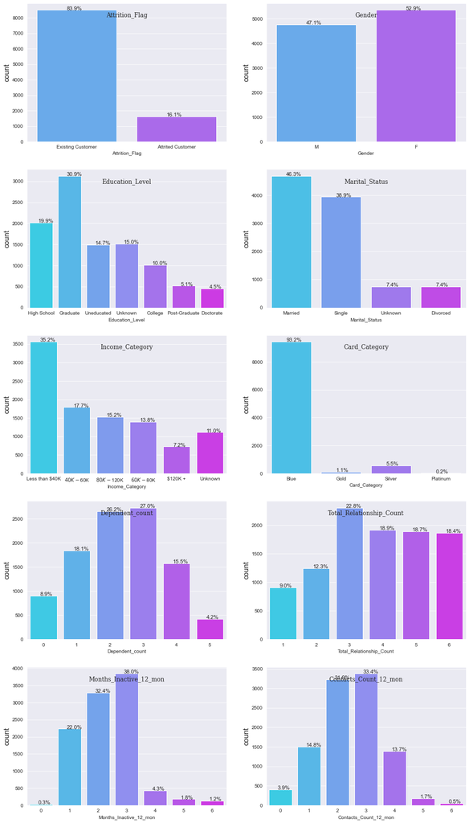

```python
# Checking categorical data (insights provided after gragh)

f = plt.figure(figsize=(16, 30))
gs = f.add_gridspec(5, 2)
i,j=0,0
for col_names in object_columns:
    ax = f.add_subplot(gs[i, j])
    ax.text(.5,.9,col_names,horizontalalignment='center',transform=ax.transAxes, family = 'serif',size = 'large')
    if col_names == 'Income_Category':
        ax1 = sns.countplot (data = df, x= col_names,palette = 'cool',order=['Less than $40K','$40K - $60K','$80K - $120K','$60K - $80K','$120K +','Unknown'])
    else:
        ax1 = sns.countplot (data = df, x= col_names,palette = 'cool')
    total = len(df[col_names]) # length of the column
    for p in ax1.patches:
        percentage = '{:.1f}%'.format(100 * p.get_height()/total) # percentage of each class of the category
        x = p.get_x() + p.get_width() / 2 - 0.1 # width of the plot
        y = p.get_y() + p.get_height()           # hieght of the plot
        ax1.annotate(percentage, (x, y), size = 11) # annotate the percantage
    ax.yaxis.label.set_size(15)
    if j==1:
        i+=1
        j=0
    else: j+=1

plt.show()
f.tight_layout()
```

### Insights:

```python
# While doing uni-variate analysis of numerical variables we want to study their central tendency
# and dispersion.
# Let us write a function that will help us create boxplot and histogram for any input numerical
# variable.
# This function takes the numerical column as the input and returns the boxplots
# and histograms for the variable.
# Let us see if this help us write faster and cleaner code.
def histogram_boxplot(feature, figsize=(15,10), bins = None):
    """ Boxplot and histogram combined
    feature: 1-d feature array
    figsize: size of fig (default (9,8))
    bins: number of bins (default None / auto)
    """
    label="Skewness: %.2f"%(feature.skew())
    f2, (ax_box2, ax_hist2) = plt.subplots(nrows = 2, # Number of rows of the subplot grid= 2
                                           sharex = True, # x-axis will be shared among all subplots
                                           gridspec_kw = {"height_ratios": (.25, .75)},
                                           figsize = figsize
                                           ) # creating the 2 subplots
    sns.boxplot(feature, ax=ax_box2, showmeans=True, color='violet') # boxplot will be created and a star will indicate the mean value of the column
    sns.distplot(feature, kde=F, ax=ax_hist2, bins=bins,color = 'orange',label = label) if bins else sns.distplot(feature, kde=False, ax=ax_hist2,color='tab:cyan',label = label) # For histogram
    ax_hist2.axvline(np.mean(feature), color='purple', linestyle='--') # Add mean to the histogram
    ax_hist2.axvline(np.median(feature), color='black', linestyle='-') # Add median to the histogram
    plt.legend(fontsize = 'x-large')
    plt.show()
```

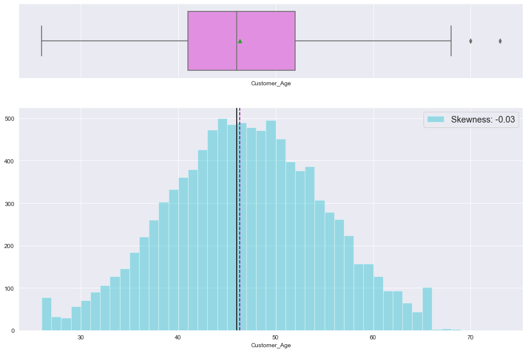

```python
histogram_boxplot(df['Customer_Age'])
```

### Insights:

- Age columns is in normal balanced diistribution with little skeness, there are 2 outliers but we will keep them.

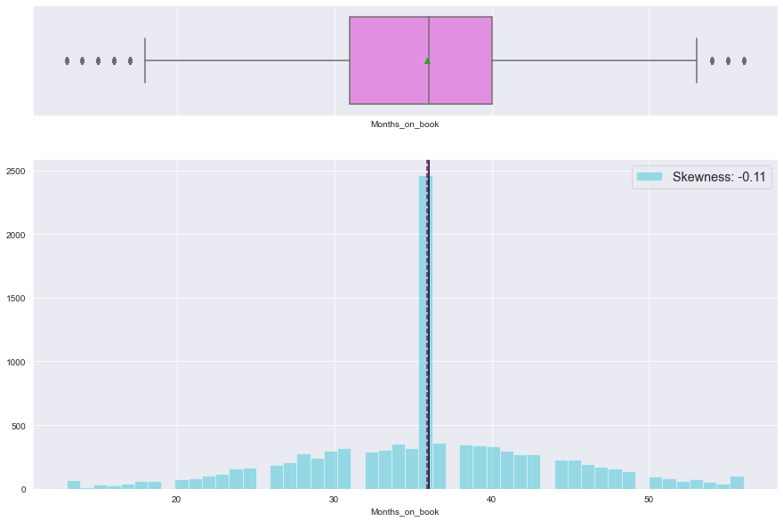

```python
histogram_boxplot(df['Months_on_book'])
```

### Insights:

- Months_on_book columns is in normal balanced distribution
- approximately 2500 customers have 36-38 months with the bank

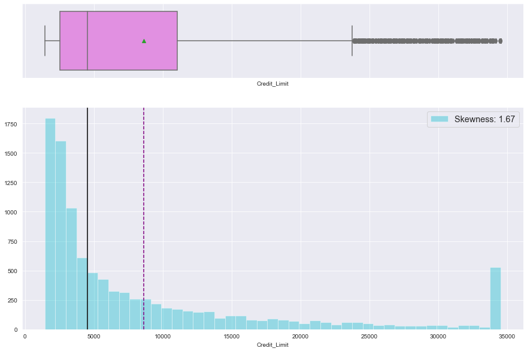

```python
histogram_boxplot(df['Credit_Limit'])
```

### Insights:

```python
df[df['Credit_Limit'] > 34500]['Credit_Limit'].value_counts()
```

```
34516.0    508
Name: Credit_Limit, dtype: int64
```

capping the value of the column to 34500

```python
df['Credit_Limit'].clip(upper=34500, inplace=True)
```

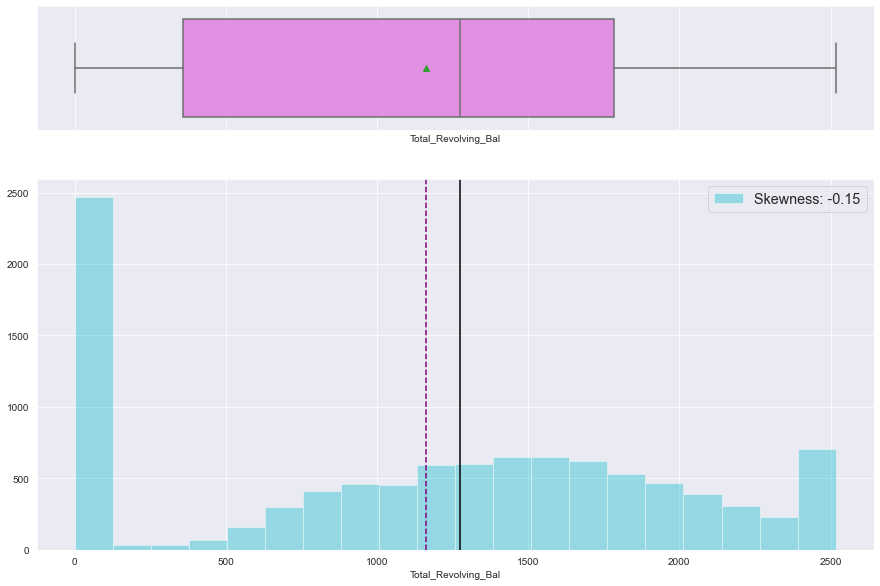

```python
histogram_boxplot(df["Total_Revolving_Bal"])
```

### Insights:

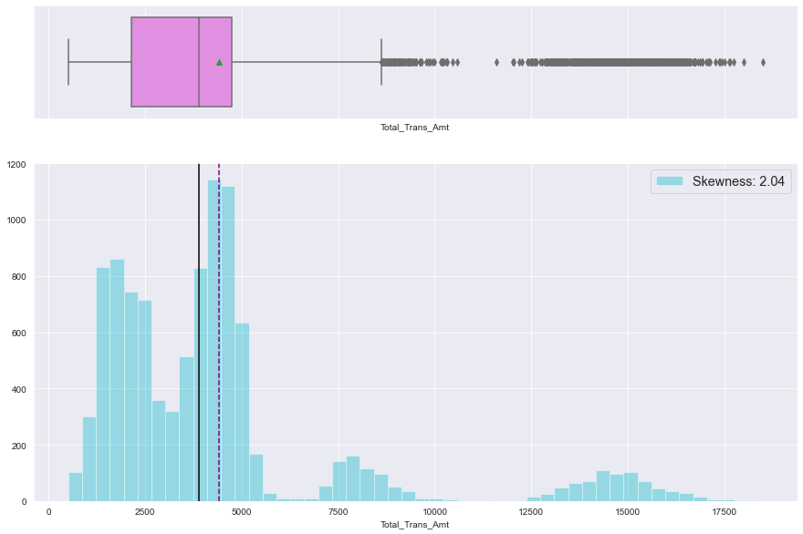

```python
histogram_boxplot(df["Total_Trans_Amt"])
```

### Insights:

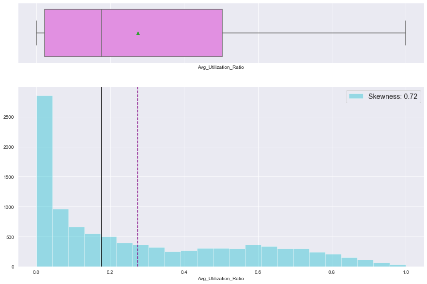

```python
histogram_boxplot(df["Avg_Utilization_Ratio"])
```

### Insights:

- Avg_Utilization_Ratio is a bit right skewed, althouhg ther are no outliers.
- apprximately 2700 customers have utlization ration between 0 to 0.1

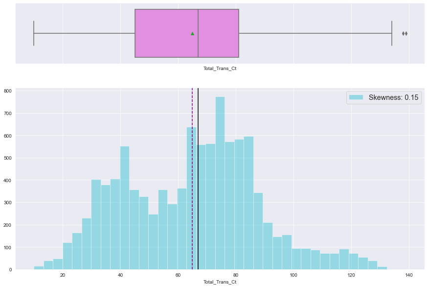

```python
histogram_boxplot(df["Total_Trans_Ct"])
```

### Insights:

- Total_Trans_Ct columns is in normal balanced diistribution with little skeness, there are 2 outliers but we will keep them.

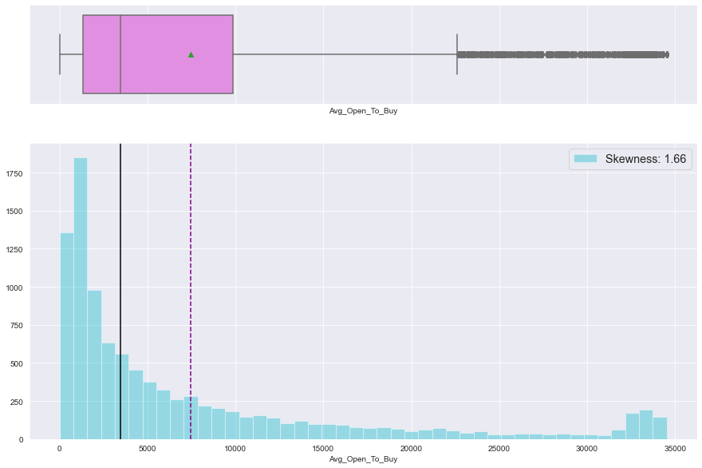

```python
histogram_boxplot(df["Avg_Open_To_Buy"])
```

### Insights:

```python
len(df[df['Avg_Open_To_Buy'] > 32000])
```

```
526
```

capping the value of the column to 32000

```python
df['Avg_Open_To_Buy'].clip(upper=32000, inplace=True)
```

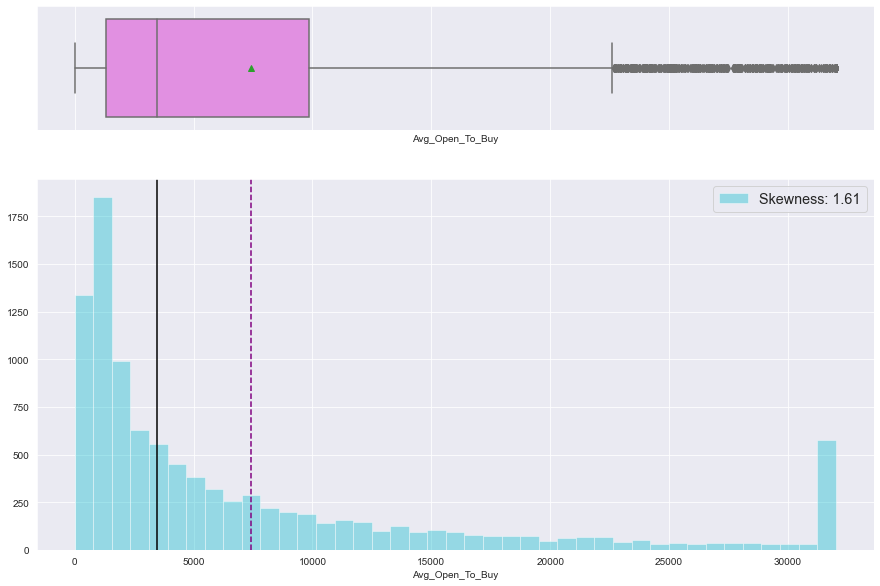

```python
# new result aftre clipping
histogram_boxplot(df["Avg_Open_To_Buy"])
```

### Bi-variate Analysis

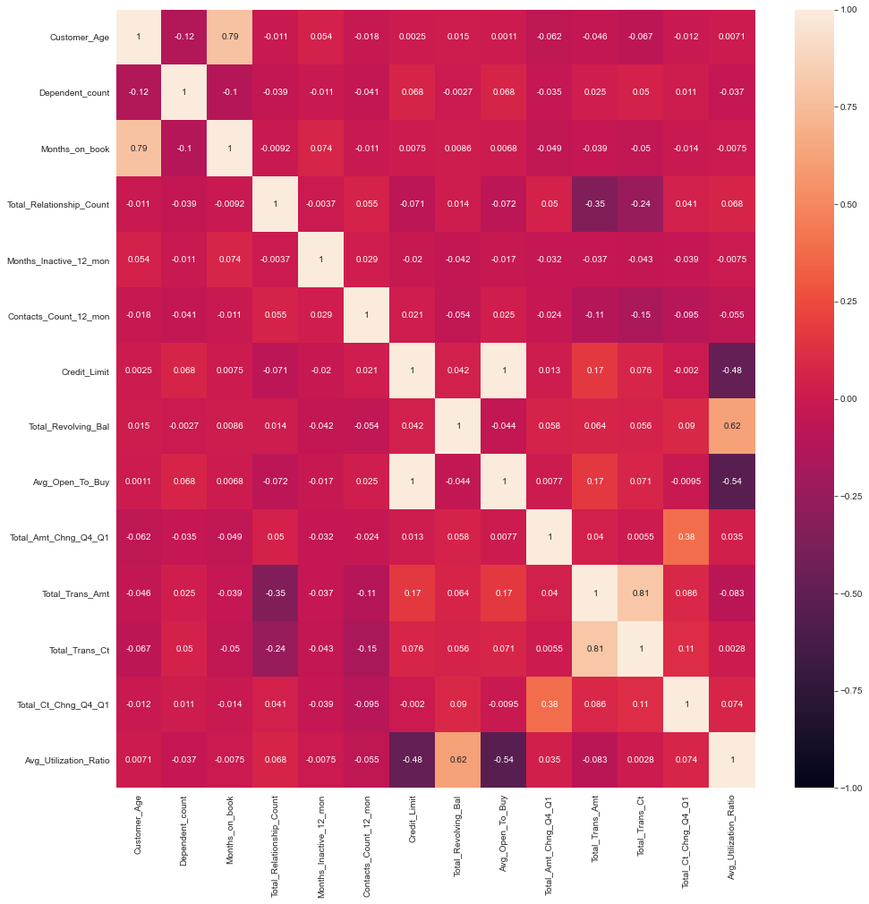

```python
plt.figure(figsize=(16,16))
sns.heatmap(df.corr(),annot=True,vmin=-1,vmax=1,fmt='.2g')
plt.show()
```

### Insights:

- Avg_Open_To_Buy and credit limit have high coorelation, we will rmeov one column value.
- Total_Trans_Amt and Total_Trans_Ct have high correlation.
- Months_on_book and age have high correlation.

```python
df.drop('Avg_Open_To_Buy', axis = 1, inplace = True)
```

```python
# this function will plot a continous variable against Target variable
def analyze_continous_var(col):
    palette = 'Accent'
    f = plt.figure(figsize=(16, 6))
    gs = f.add_gridspec(1, 3)
    ax = f.add_subplot(gs[0, 0])
    plot1 = sns.boxplot(y=col,x='Attrition_Flag',data=df,palette = palette, linewidth= 0.5)
    #ax = f.add_subplot(gs[1, 0])
    #sns.violinplot(y='age',x='Target',data=df,palette = 'Accent')
    ax = f.add_subplot(gs[0, 1])
    plot2 = sns.stripplot(y=col,x='Attrition_Flag',data=df,palette = palette, jitter=0.30, linewidth= 0.1, edgecolor ='blue')
    ax = f.add_subplot(gs[0, 2])
    plot2 = sns.violinplot(y=col,x='Attrition_Flag',data=df,palette = palette, linewidth= 0.5)
    plt.show()
```

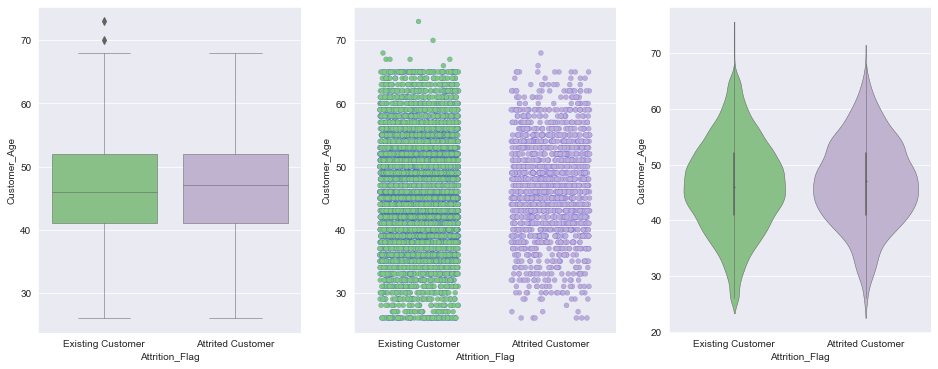

```python
analyze_continous_var('Customer_Age')
```

**Insights**:

- There is no strong relationship between age and target variable.

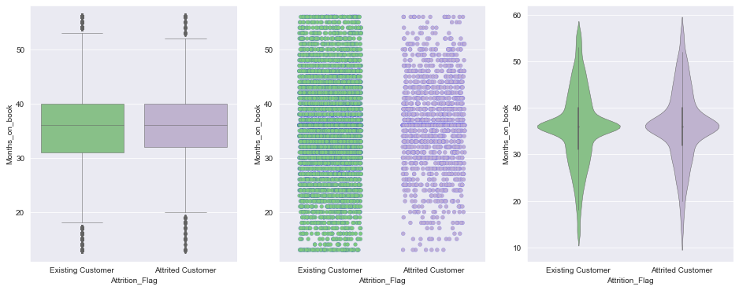

```python
analyze_continous_var('Months_on_book')
```

**Insights**:

- period of relationship with bank is not a strong indicator of attrition flag.
- there are less attried customers, but over characterstcs of exsiting vs attrited customers are same for month_on_books

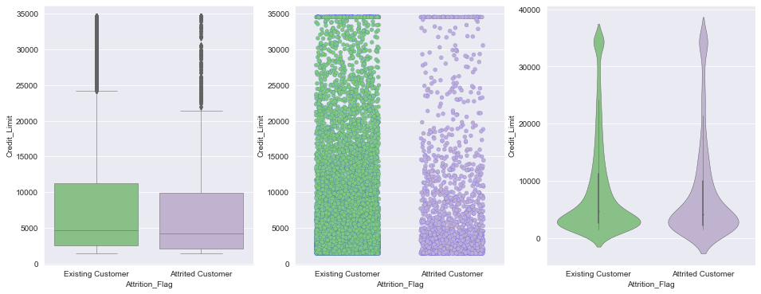

```python
analyze_continous_var('Credit_Limit')
```

**Insights**:

- Customers with higher Credit_limit are existing customers. the avregae is slightly higher, but there is aevidence to provethis hypothesis.

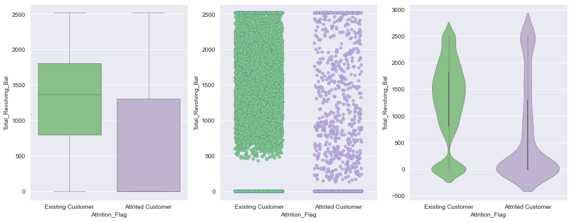

```python
analyze_continous_var('Total_Revolving_Bal')
```

**Insights**:

- Customers with higher Revolving Balance have less chnaces of leaving.
- there is a strong relationship
- most of the Attrited customers have lower recolving balance

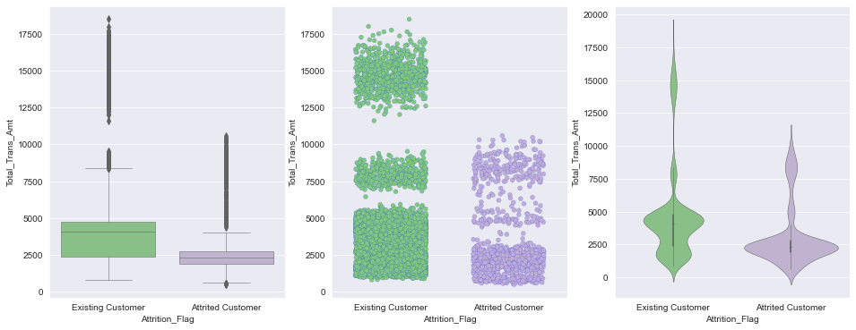

```python
analyze_continous_var('Total_Trans_Amt')
```

**Insights**:

- Customers with higher transaction Amount in last 12 months have very less chnaces of leavng.
- there is strong evidence to prove this.

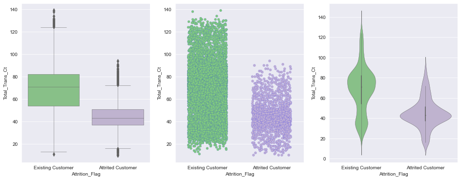

```python
analyze_continous_var('Total_Trans_Ct')
```

**Insights**:

- Customers doing more transactions with bank, have less chnaces of leaving te bank.

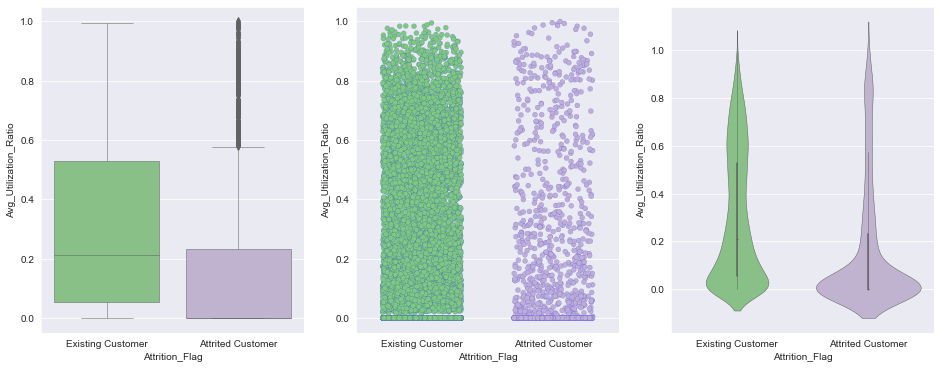

```python
analyze_continous_var('Avg_Utilization_Ratio')
```

**Insights**:

- Customers using their card more will have more chnaces of staying with bank

### Checking Categorical data individually w.r.t Target variable

The function created below will create a graph - The graph will display all categories and for each category it will simply display % of Customers for category

```python
def display_categorical_data(col):
    f= plt.figure(figsize=(14,6))
    todal_n= []
    i=0
    ax_plot2 = sns.countplot (data = df, x= col,hue= 'Attrition_Flag',palette = 'plasma_r')
    ax_plot2.text(.1,.7,'Percentage of Customers left the bank',horizontalalignment='center',verticalalignment='top',transform=ax.transAxes, family = 'serif',size = 'large')
    cnt = df[col].nunique()
    for p in ax_plot2.patches:
        todal_n.append(p.get_height())
        x = p.get_x() + p.get_width() / 2 - 0.1 # width of the plot
        y = p.get_y() + p.get_height()           # hieght of the plot
        if i>= cnt:
            per = '{:.1f}%'.format(todal_n[i]*100/todal_n[i-cnt])
            ax_plot2.annotate(per, (x, y), size = 11) # annotate the percantage
        i+=1
    ax_plot2.yaxis.label.set_size(15)
    ax_plot2.xaxis.label.set_size(12)
    if col == 'job':
        plt.xticks(rotation=30)

    plt.show()
```

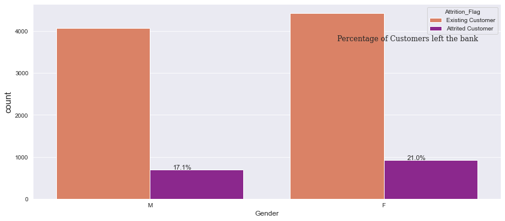

```python
display_categorical_data('Gender')
```

**Insights**:

- 21% of females leave the bank as compared to 17% males

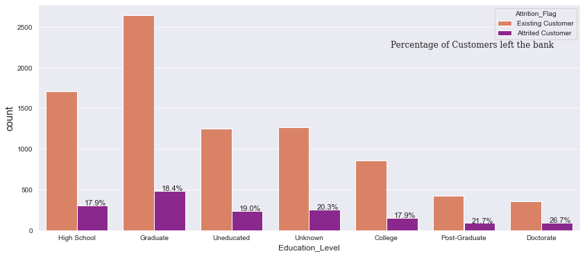

```python
display_categorical_data('Education_Level')
```

**Insights**:

- 26.7% of dcotorrates and 21.7 % post gradutaes are leaving the bank.

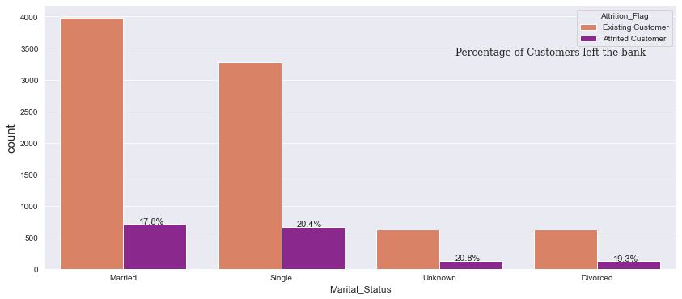

```python
display_categorical_data('Marital_Status')
```

**Insights**:

- Most people leaving the bank are either single or unknown status
- unknown status cannot be clubbed with any othe becasue it has completely different chacterstics

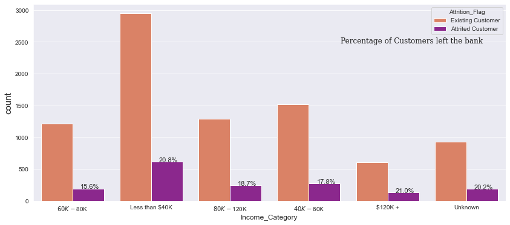

```python
display_categorical_data('Income_Category')
```

**Insights**:

- people earning 120k + are the highest % leaving the bank whihc is 21%

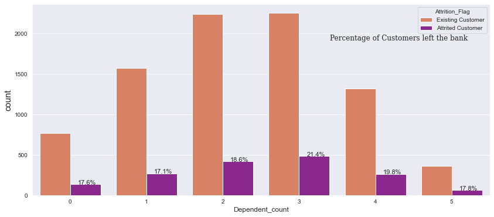

```python
display_categorical_data('Dependent_count')
```

**Insights**:

- people with 3 depndants are highest in leaving, althought this doesnt seem to be a good coorrelation.

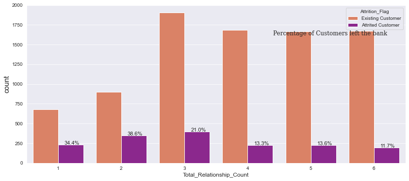

```python
display_categorical_data('Total_Relationship_Count')
```

**Insights**:

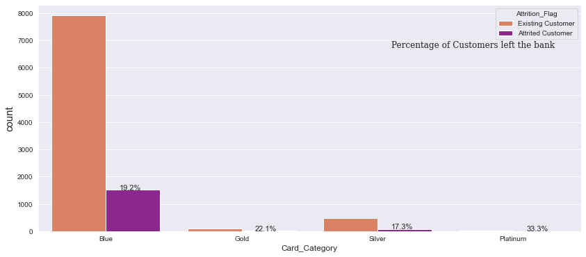

```python
display_categorical_data('Card_Category')
```

**Insights**:

- poeple with platinum card are leaving the bank at 33%, altough the count is very less

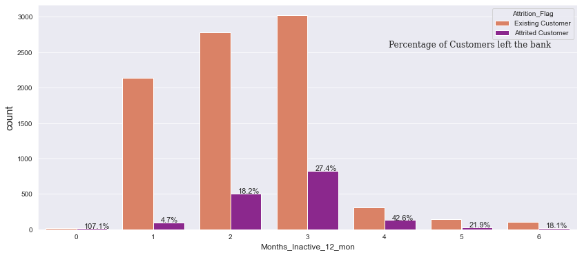

```python
display_categorical_data('Months_Inactive_12_mon')
```

**Insights**:

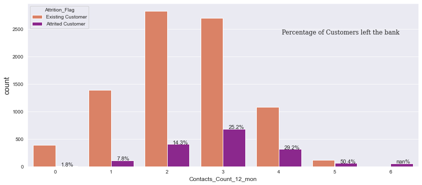

```python
display_categorical_data('Contacts_Count_12_mon')
```

**Insights**:

# Feature Engineering

```python
df[object_columns]
```

|  | Attrition_Flag | Gender | Education_Level | Marital_Status | Income_Category | Card_Category | Dependent_count | Total_Relationship_Count | Months_Inactive_12_mon | Contacts_Count_12_mon |
| --- | --- | --- | --- | --- | --- | --- | --- | --- | --- | --- |
| 0 | Existing Customer | M | High School | Married | $60K - $80K | Blue | 3 | 5 | 1 | 3 |
| 1 | Existing Customer | F | Graduate | Single | Less than $40K | Blue | 5 | 6 | 1 | 2 |
| 2 | Existing Customer | M | Graduate | Married | $80K - $120K | Blue | 3 | 4 | 1 | 0 |
| 3 | Existing Customer | F | High School | Unknown | Less than $40K | Blue | 4 | 3 | 4 | 1 |
| 4 | Existing Customer | M | Uneducated | Married | $60K - $80K | Blue | 3 | 5 | 1 | 0 |
| ... | ... | ... | ... | ... | ... | ... | ... | ... | ... | ... |
| 10122 | Existing Customer | M | Graduate | Single | $40K - $60K | Blue | 2 | 3 | 2 | 3 |
| 10123 | Attrited Customer | M | Unknown | Divorced | $40K - $60K | Blue | 2 | 4 | 2 | 3 |
| 10124 | Attrited Customer | F | High School | Married | Less than $40K | Blue | 1 | 5 | 3 | 4 |
| 10125 | Attrited Customer | M | Graduate | Unknown | $40K - $60K | Blue | 2 | 4 | 3 | 3 |
| 10126 | Attrited Customer | F | Graduate | Married | Less than $40K | Silver | 2 | 6 | 2 | 4 |

10127 rows × 10 columns

### Checking unique values and count of every value in every object column

**We will also check percentage of rows for every categorical value vs overall rows in the dataframe**

```python
#print unique values and counts for all Categorical columns; we will convert these columns and compare these counts later
object_columns = list(df.describe(include=['object']).T.index)
total_rows = len(df)
for col in object_columns:
    print(f'Unique values count and % for column "{col}" are:\n')
    vc = pd.DataFrame(df[col].value_counts())
    vc['per'] = round(vc[col]/total_rows*100)
    vc.columns = ['Count','Percentage of Overall Data']
    print(tabulate(vc, headers = 'keys', tablefmt = 'fancy_grid'))
```

```
Unique values count and % for column "Attrition_Flag" are:

╒═══════════════════╤═════════╤══════════════════════════════╕
│                   │   Count │   Percentage of Overall Data │
╞═══════════════════╪═════════╪══════════════════════════════╡
│ Existing Customer │    8500 │                           84 │
├───────────────────┼─────────┼──────────────────────────────┤
│ Attrited Customer │    1627 │                           16 │
╘═══════════════════╧═════════╧══════════════════════════════╛
Unique values count and % for column "Gender" are:

╒════╤═════════╤══════════════════════════════╕
│    │   Count │   Percentage of Overall Data │
╞════╪═════════╪══════════════════════════════╡
│ F  │    5358 │                           53 │
├────┼─────────┼──────────────────────────────┤
│ M  │    4769 │                           47 │
╘════╧═════════╧══════════════════════════════╛
Unique values count and % for column "Education_Level" are:

╒═══════════════╤═════════╤══════════════════════════════╕
│               │   Count │   Percentage of Overall Data │
╞═══════════════╪═════════╪══════════════════════════════╡
│ Graduate      │    3128 │                           31 │
├───────────────┼─────────┼──────────────────────────────┤
│ High School   │    2013 │                           20 │
├───────────────┼─────────┼──────────────────────────────┤
│ Unknown       │    1519 │                           15 │
├───────────────┼─────────┼──────────────────────────────┤
│ Uneducated    │    1487 │                           15 │
├───────────────┼─────────┼──────────────────────────────┤
│ College       │    1013 │                           10 │
├───────────────┼─────────┼──────────────────────────────┤
│ Post-Graduate │     516 │                            5 │
├───────────────┼─────────┼──────────────────────────────┤
│ Doctorate     │     451 │                            4 │
╘═══════════════╧═════════╧══════════════════════════════╛
Unique values count and % for column "Marital_Status" are:

╒══════════╤═════════╤══════════════════════════════╕
```

[output cut: 25 more lines]

```
│ $120K +        │     727 │                            7 │
╘════════════════╧═════════╧══════════════════════════════╛
Unique values count and % for column "Card_Category" are:

╒══════════╤═════════╤══════════════════════════════╕
│          │   Count │   Percentage of Overall Data │
╞══════════╪═════════╪══════════════════════════════╡
│ Blue     │    9436 │                           93 │
├──────────┼─────────┼──────────────────────────────┤
│ Silver   │     555 │                            5 │
├──────────┼─────────┼──────────────────────────────┤
│ Gold     │     116 │                            1 │
├──────────┼─────────┼──────────────────────────────┤
│ Platinum │      20 │                            0 │
╘══════════╧═════════╧══════════════════════════════╛
```

### Categorical & one-hot encoding

```python
Attrition_Flag = {'Existing Customer':0,'Attrited Customer':1}
df['Attrition_Flag'] = df['Attrition_Flag'].map(Attrition_Flag)
df['Attrition_Flag'].value_counts()
```

```
0    8500
1    1627
Name: Attrition_Flag, dtype: int64
```

```python
X = df.drop(['Attrition_Flag'],axis=1)
y = df['Attrition_Flag']
```

```python
print(X.shape)
print(y.shape)
```

```
(10127, 18)
(10127,)
```

```python
X = pd.get_dummies(X,drop_first=True)
```

```python
print(X.shape)
print(y.shape)
```

```
(10127, 31)
(10127,)
```

## Split the data into training and test set in the ratio of 70:30 respectively

```python
# Splitting data into training and test set:
X_train, X_test, y_train, y_test = train_test_split(X, y, test_size=0.3, random_state=7,stratify=y)
print(X_train.shape, X_test.shape)
```

```
(7088, 31) (3039, 31)
```

# Building the model

```python
##  Function to calculate different metric scores of the model - Accuracy, Recall and Precision
def get_metrics_score(model,train,test,train_y,test_y,flag=True):
    '''
    model : classifier to predict values of X

    '''
    # defining an empty list to store train and test results
    score_list=[]

    pred_train = model.predict(train)
    pred_test = model.predict(test)

    train_acc = model.score(train,train_y)
    test_acc = model.score(test,test_y)

    train_recall = metrics.recall_score(train_y,pred_train)
    test_recall = metrics.recall_score(test_y,pred_test)

    train_precision = metrics.precision_score(train_y,pred_train)
    test_precision = metrics.precision_score(test_y,pred_test)

    score_list.extend((train_acc,test_acc,train_recall,test_recall,train_precision,test_precision))

    # If the flag is set to True then only the following print statements will be dispayed. The default value is set to True.
    if flag == True:
        print("Accuracy on training set : ",model.score(train,train_y))
        print("Accuracy on test set : ",model.score(test,test_y))
        print("Recall on training set : ",metrics.recall_score(train_y,pred_train))
        print("Recall on test set : ",metrics.recall_score(test_y,pred_test))
        print("Precision on training set : ",metrics.precision_score(train_y,pred_train))
        print("Precision on test set : ",metrics.precision_score(test_y,pred_test))

    return score_list
```

```python
def make_confusion_matrix(model,y_actual,labels=[1, 0]):
    '''
    model : classifier to predict values of X
    y_actual : ground truth

    '''
    y_predict = model.predict(X_test)
    cm=metrics.confusion_matrix( y_actual, y_predict, labels=[0, 1])
    df_cm = pd.DataFrame(cm, index = [i for i in ["Actual - No","Actual - Yes"]],
                  columns = [i for i in ['Predicted - No','Predicted - Yes']])
    group_counts = ["{0:0.0f}".format(value) for value in
                cm.flatten()]
    group_percentages = ["{0:.2%}".format(value) for value in
                         cm.flatten()/np.sum(cm)]
    labels = [f"{v1}\n{v2}" for v1, v2 in
              zip(group_counts,group_percentages)]
    labels = np.asarray(labels).reshape(2,2)
    plt.figure(figsize = (10,7))
    sns.heatmap(df_cm, annot=labels,fmt='')
    plt.ylabel('True label')
    plt.xlabel('Predicted label')
```

## Logistic Regression

```python
lr = LogisticRegression(random_state=1)
lr.fit(X_train,y_train)
```

```
LogisticRegression(random_state=1)
```

```
Accuracy on training set :  0.8899548532731377
Accuracy on test set :  0.8868048700230339
Recall on training set :  0.49692712906057945
Recall on test set :  0.4651639344262295
Precision on training set :  0.7322121604139715
Precision on test set :  0.7322580645161291
```

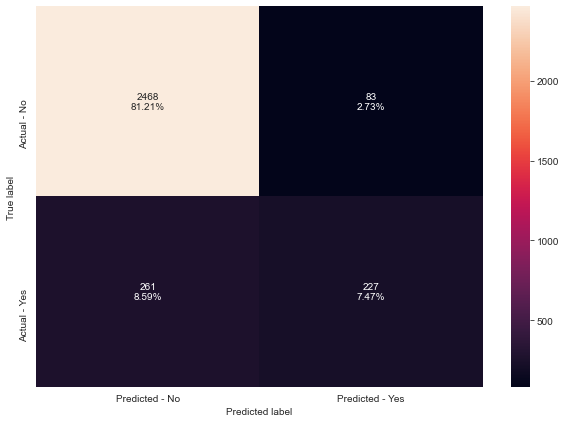

```python
#Calculating different metrics
scores_LR = get_metrics_score(lr,X_train,X_test,y_train,y_test)

# creating confusion matrix
make_confusion_matrix(lr,y_test)
```

## Oversampling train data using SMOTE

```python
print("Before UpSampling, counts of label 'Yes': {}".format(sum(y_train==1)))
print("Before UpSampling, counts of label 'No': {} \n".format(sum(y_train==0)))

sm = SMOTE(sampling_strategy = 1 ,k_neighbors = 5, random_state=1)   #Synthetic Minority Over Sampling Technique
```

```
Before UpSampling, counts of label 'Yes': 1139
Before UpSampling, counts of label 'No': 5949
```

```python
X_train_over, y_train_over = sm.fit_resample(X_train, y_train)

print("After UpSampling, counts of label 'Yes': {}".format(sum(y_train_over==1)))
print("After UpSampling, counts of label 'No': {} \n".format(sum(y_train_over==0)))

print('After UpSampling, the shape of train_X: {}'.format(X_train_over.shape))
print('After UpSampling, the shape of train_y: {} \n'.format(y_train_over.shape))
```

```
After UpSampling, counts of label 'Yes': 5949
After UpSampling, counts of label 'No': 5949

After UpSampling, the shape of train_X: (11898, 31)
After UpSampling, the shape of train_y: (11898,)
```

## Logistic Regression on oversampled data

```python
log_reg_over = LogisticRegression(random_state = 1)

# Training the basic logistic regression model with training set
log_reg_over.fit(X_train_over,y_train_over)
```

```
LogisticRegression(random_state=1)
```

```
Accuracy on training set :  0.7986216170785005
Accuracy on test set :  0.7996051332675223
Recall on training set :  0.7949235165574046
Recall on test set :  0.7745901639344263
Precision on training set :  0.8008467400508044
Precision on test set :  0.43101482326111745
```

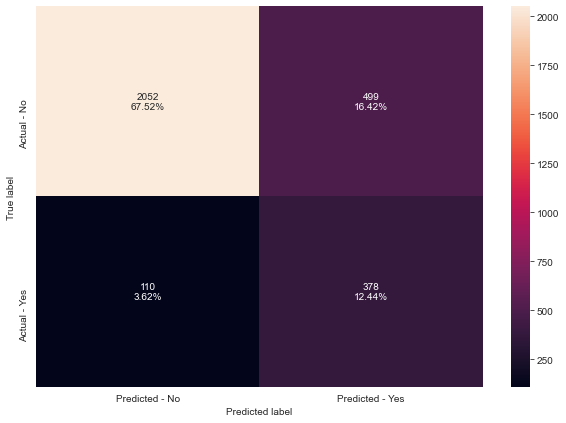

```python
#Calculating different metrics
get_metrics_score(log_reg_over,X_train_over,X_test,y_train_over,y_test)

# creating confusion matrix
make_confusion_matrix(log_reg_over,y_test)
```

**Insights**:

- Accuracy on on test set hs decreased from 88 to 79
- recall on test set has increased from 46 to 77
- precision on test set has decreased om 73 to 43

**Recall is an important metric here, as we need ot corectly predict the cutomes leaivn and avoid false negatives**

## Regularization

```python
# Choose the type of classifier.
lr_estimator = LogisticRegression(random_state=1,solver='saga')

# Grid of parameters to choose from
parameters = {'C': np.arange(0.1,1.1,0.1)}

# Run the grid search
grid_obj = GridSearchCV(lr_estimator, parameters, scoring='recall')
grid_obj = grid_obj.fit(X_train_over, y_train_over)

# Set the clf to the best combination of parameters
lr_estimator = grid_obj.best_estimator_

# Fit the best algorithm to the data.
lr_estimator.fit(X_train_over, y_train_over)
```

```
LogisticRegression(C=0.1, random_state=1, solver='saga')
```

```
Accuracy on training set :  0.7088586317028072
Accuracy on test set :  0.7900625205659757
Recall on training set :  0.601949907547487
Recall on test set :  0.5799180327868853
Precision on training set :  0.7656617489843917
Precision on test set :  0.3952513966480447
```

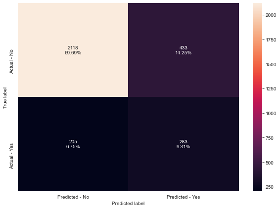

```python
#Calculating different metrics
get_metrics_score(lr_estimator,X_train_over,X_test,y_train_over,y_test)

# creating confusion matrix
make_confusion_matrix(lr_estimator,y_test)
```

**Insights**:

- Accuracy on on test set hs decreased from 88 to 79
- recall on test set has increased from 46 to 58
- precision on test set has decreased om 73 to 39

this model has poor performance

## Undersampling train data using RandomUnderSampler

```python
rus = RandomUnderSampler(random_state = 1)
X_train_un, y_train_un = rus.fit_resample(X_train, y_train)
```

```python
print("Before Under Sampling, counts of label 'Yes': {}".format(sum(y_train==1)))
print("Before Under Sampling, counts of label 'No': {} \n".format(sum(y_train==0)))

print("After Under Sampling, counts of label 'Yes': {}".format(sum(y_train_un==1)))
print("After Under Sampling, counts of label 'No': {} \n".format(sum(y_train_un==0)))

print('After Under Sampling, the shape of train_X: {}'.format(X_train_un.shape))
print('After Under Sampling, the shape of train_y: {} \n'.format(y_train_un.shape))
```

```
Before Under Sampling, counts of label 'Yes': 1139
Before Under Sampling, counts of label 'No': 5949

After Under Sampling, counts of label 'Yes': 1139
After Under Sampling, counts of label 'No': 1139

After Under Sampling, the shape of train_X: (2278, 31)
After Under Sampling, the shape of train_y: (2278,)
```

## Logistic Regression on undersampled data

```python
log_reg_under = LogisticRegression(random_state = 1)
log_reg_under.fit(X_train_un,y_train_un )
```

```
LogisticRegression(random_state=1)
```

```
Accuracy on training set :  0.820017559262511
Accuracy on test set :  0.8150707469562356
Recall on training set :  0.8270412642669008
Recall on test set :  0.7991803278688525
Precision on training set :  0.8155844155844156
Precision on test set :  0.4566744730679157
```

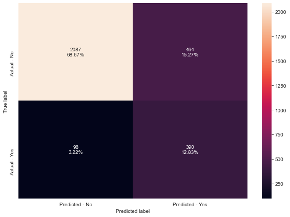

```python
#Calculating different metrics
get_metrics_score(log_reg_under,X_train_un,X_test,y_train_un,y_test)

# creating confusion matrix
make_confusion_matrix(log_reg_under,y_test)
```

**Insights**:

- Accuracy on on test set hs decreased from 88 to 82
- recall on test set has increased from 46 to 79
- precision on test set has decreased om 73 to 46

This model performed betetr than above modles, but the data was reduced significantly to achive the performance

# PIPELINES

## Model building - Bagging and Boosting

```python
models = []  # Empty list to store all the models

# Appending pipelines for each model into the list
models.append(
    (
        "LR",
        Pipeline(
            steps=[
                ("scaler", StandardScaler()),
                ("log_reg", LogisticRegression(random_state=1)),
            ]
        ),
    )
)
models.append(
    (
        "RF",
        Pipeline(
            steps=[
                ("scaler", StandardScaler()),
                ("random_forest", RandomForestClassifier(random_state=1)),
            ]
        ),
    )
)
models.append(
    (
        "GBM",
        Pipeline(
            steps=[
                ("scaler", StandardScaler()),
                ("gradient_boosting", GradientBoostingClassifier(random_state=1)),
            ]
        ),
    )
)
models.append(
    (
        "ADB",
        Pipeline(
            steps=[
                ("scaler", StandardScaler()),
                ("adaboost", AdaBoostClassifier(random_state=1)),
            ]
        ),
    )
)
models.append(
    (
        "XGB",
        Pipeline(
            steps=[
                ("scaler", StandardScaler()),
                ("xgboost", XGBClassifier(random_state=1,eval_metric='logloss')),
            ]
        ),
    )
)
models.append(
    (
        "DTREE",
        Pipeline(
            steps=[
                ("scaler", StandardScaler()),
                ("decision_tree", DecisionTreeClassifier(random_state=1)),
            ]
        ),
    )
)
models
```

```
[('LR',
  Pipeline(steps=[('scaler', StandardScaler()),
                  ('log_reg', LogisticRegression(random_state=1))])),
 ('RF',
  Pipeline(steps=[('scaler', StandardScaler()),
                  ('random_forest', RandomForestClassifier(random_state=1))])),
 ('GBM',
  Pipeline(steps=[('scaler', StandardScaler()),
                  ('gradient_boosting',
                   GradientBoostingClassifier(random_state=1))])),
 ('ADB',
  Pipeline(steps=[('scaler', StandardScaler()),
                  ('adaboost', AdaBoostClassifier(random_state=1))])),
 ('XGB',
  Pipeline(steps=[('scaler', StandardScaler()),
                  ('xgboost',
                   XGBClassifier(base_score=None, booster=None,
                                 colsample_bylevel=None, colsample_bynode=None,
                                 colsample_bytree=None, eval_metric='logloss',
                                 gamma=None, gpu_id=None, importance_type='gain',
                                 interaction_constraints=None, learning_rate=None,
                                 max_delta_step=None, max_depth=None,
                                 min_child_weight=None, missing=nan,
                                 monotone_constraints=None, n_estimators=100,
                                 n_jobs=None, num_parallel_tree=None,
                                 random_state=1, reg_alpha=None, reg_lambda=None,
                                 scale_pos_weight=None, subsample=None,
                                 tree_method=None, validate_parameters=None,
                                 verbosity=None))])),
 ('DTREE',
  Pipeline(steps=[('scaler', StandardScaler()),
                  ('decision_tree', DecisionTreeClassifier(random_state=1))]))]
```

```python
models[0]
```

```
('LR',
 Pipeline(steps=[('scaler', StandardScaler()),
                 ('log_reg', LogisticRegression(random_state=1))]))
```

```python
results = []  # Empty list to store all model's CV scores
names = []  # Empty list to store name of the models

# loop through all models to get the mean cross validated score
for name, model in models:
    scoring = "recall"
    kfold = StratifiedKFold(n_splits=5, shuffle=True, random_state=1)
    cv_result = cross_val_score(estimator=model, X=X_train, y=y_train, scoring=scoring, cv=kfold)
    results.append(cv_result)
    names.append(name)
    print(f"{name}: {cv_result.mean() * 100}")
```

```
LR: 58.73483267640467
RF: 78.05162686451813
GBM: 85.16152716593245
ADB: 83.49447407063914
XGB: 88.76381482340211
DTREE: 78.66604838086404
```

**Insights**:

- XG boost is providing the best mean results, gradient boost is close second.
- however we should not just trust mean result as we should look into the max value as well
- below we plot the all results for all models we trained above.

```python
results
```

```
[array([0.63596491, 0.52192982, 0.60964912, 0.59210526, 0.57709251]),
 array([0.81578947, 0.79824561, 0.73684211, 0.76315789, 0.78854626]),
 array([0.87280702, 0.83333333, 0.83333333, 0.87719298, 0.84140969]),
 array([0.88157895, 0.81140351, 0.81578947, 0.82894737, 0.83700441]),
 array([0.9122807 , 0.86842105, 0.87280702, 0.87719298, 0.90748899]),
 array([0.80701754, 0.77631579, 0.78070175, 0.77631579, 0.79295154])]
```

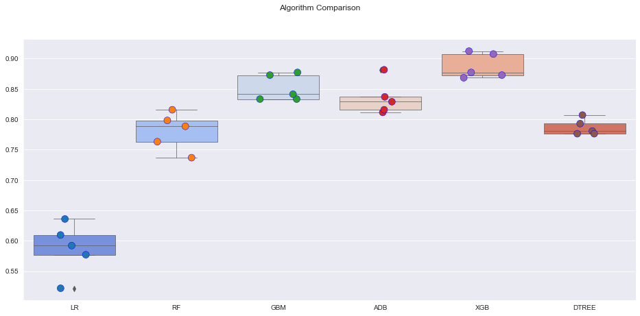

```python
fig = plt.figure(figsize=(16, 7))

fig.suptitle("Algorithm Comparison")
ax = fig.add_subplot(111)

sns.stripplot(data=results,  linewidth= 0.5, edgecolor ='blue',size=10, jitter = 0.2)
sns.boxplot(data=results, linewidth= 0.7,palette = 'coolwarm')
ax.set_xticklabels(names)

plt.show()
```

**Insights**:

- XG boost hs not only the highest mean but has the highest maximum value as well
- Therefore XGboost is the preffered model here.

# Model Performances

- Compare the model performance of all the models - Comment on the time taken by the grid and randomized search in optimization

## Hyperparameter Tuning

We will use pipelines with StandardScaler and **XGBOOST** model and tune the model using GridSearchCV and RandomizedSearchCV. We will also compare the performance and time taken by these two methods - grid search and randomized search.

## XGBOOST with GridSearchCV

```python
%%time

# Creating pipeline
pipe = make_pipeline(StandardScaler(), XGBClassifier(random_state=1))

# Parameter grid to pass in GridSearchCV
parameters = {'xgbclassifier__n_estimators': [75,100,125,150],
              'xgbclassifier__subsample':[0.7, 0.8, 0.9, 1],
              'xgbclassifier__gamma':[0, 1, 3, 5],
              'xgbclassifier__colsample_bytree':[0.7, 0.8, 0.9, 1]
              }

# Type of scoring used to compare parameter combinations
scorer = metrics.make_scorer(metrics.recall_score)

# Calling GridSearchCV
grid_cv = GridSearchCV(estimator=pipe, param_grid=parameters, scoring=scorer, cv=5)

# Fitting parameters in GridSeachCV
grid_cv.fit(X_train, y_train)

print("Best Parameters:{} \nScore: {}".format(grid_cv.best_params_, grid_cv.best_score_))
```

[output not shown]

[output cut: 1267 more lines]